# scatter_plot_logx

```r
library(fancyplots)
library(tidyverse)
library(gapminder)
```

`scatter_plot_logx`

HELLO! This vignette is essentially my README.md for the package. ENJOY!

## Examples with `scatter_plot_logx`

#### making scatterplots with a logarithmically scaled x axis!!!

(the only function in this package :sweat_smile:)

##### Example 1: Numerical Y Axis

Here is how `fancyplots` *scatter_plot_x* function works with the gapminder dataset. In this example, our y axis will be *lifeExp*, which contains the average life expectancy of each country over the years.

This graph shows *population vs life expectancy* in the countries of Asia from 1952-2007.

```
#> Removing NA values from the data set...
#> Plotting columns "pop" vs  "lifeExp"
#> Printing plot...
```

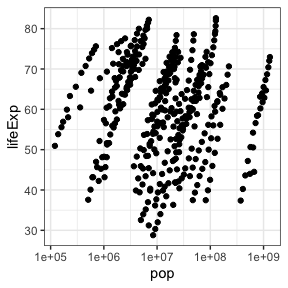

```r
library(fancyplots)
library(gapminder)
example1 <- filter(gapminder, continent == "Asia")
scatter_plot_logx(example1, "pop", "lifeExp")
```

##### Example 2: Factors as the Y Axis

Here is how `fancyplots` *scatter_plot_x* function works with the gapminder dataset. In this example, our y axis will be *continent*.

This graph shows us the spread of the population in the countries of each continent in 2007.

```
#> Removing NA values from the data set...
#> Plotting columns "pop" vs  "continent"
#> Printing plot...
```

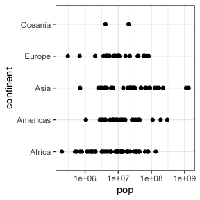

```r
library(fancyplots)
example2 <- filter(gapminder, year == 2007)
scatter_plot_logx(example2, "pop", "continent")
```

## Default Features

##### `na.omit`

The `scale_log_x` by default removes any NA’s within your dataset via **na.omit** = TRUE!

Below is plotting of example 1 with multiple NAs inserted.

```
#> Removing NA values from the data set...
#> Plotting columns "pop" vs  "lifeExp"
#> Printing plot...
#> Warning: Removed 101 rows containing missing values (geom_point).
```

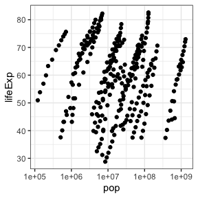

```r
#adding NAs to rows 150-250
example1[150:250, ] <- NA

scatter_plot_logx(example1, "pop", "lifeExp", na.omit = TRUE)
```

##### `logx`

The `scale_log_x` by default scales the x axis of your plot via **logx** = TRUE!

Below is example 2, plotting with **logx** = FALSE

```
#> Removing NA values from the data set...
#> Plotting columns "pop" vs  "continent"
#> Printing plot...
```

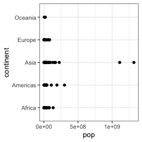

```r
scatter_plot_logx(example2, "pop", "continent", logx = FALSE)
```

##### `verbose`

Finally, the `scale_log_x` by default has a **verbose** option set to TRUE! This prints those update messages one sees prior to the plot. You can similarly turn off these messages by making **verbose** equal to FALSE.